# Chapter_12_Tutorial

Fiona Harrigian and Tshianeo Ndou

2025-11-08

```r
#NEED TO MAKE SURE INCLUDES ALL PACKAGES

library(dplyr)
library(kableExtra)
#install.packages("rio")
library(dplyr, tidyverse, rio)
```

# 1 Introduction

Throughout this semester, we have discussed making our science reproducible and accessible. We started by learning the concept of reproducible science and why it is so important. We also learned that there is a reproducibility crisis, what might be causing it, and how to address it. To address writing reproducible code, we learned about R markdown files and how to format them in a clear, reproducible way. We next learned how to make bibliographies, appendices, tables, figures, citations, and references in R markdown and how to use settings to best display them. We learned about creating and using functions and lists in R and writing code in a clear, reproducible, and defensive way.

Then, we discussed the scientific method and how to mitigate the threats to each step of the scientific process. One of the mitigation strategies is using the TOP (Transparency and Openness Promotion) Guidelines, another is the OSF (Open Science Framework). Other mitigation strategies include the FAIR and CARE principles. FAIR principles focus on making data accessible to everyone, whereas CARE principles apply specifically to data involving Indigenous People and emphasize considerations of who benefits from the data, who can collect the data and the responsibilities and ethics surrounding the data. They are technically in opposition to each other but are equally important to consider when conducting research and before sharing data. Connected to this was the concept of a Creative Common license and which would be best to use for your own research.

Finally, we learned about data management, that it is best to create a data management plan before starting research, and how to manage your data in a way that means it will continue to usable by you, your colleagues, and the general public, as long as such accessibility has been checked by the CARE principles.

One of the final pieces of making your science reproducible is making sure your data and code are accessible, again and importantly considering the FAIR and CARE principles. During this tutorial, we will introduce Git and Github, which will help make your science more reproducible. Early in this semester, we were given a definition of reproducible science that included having data and code be publicly available.

## 1.1 Git and GitHub

Git is a version control system, which keeps track of the changes made to the files stored within it and allows us to return to previous versions. GitHub is the cloud hosting service built on top of Git. It can store data for you remotely, solving the issue of data storage. However, it was not built specifically for researchers, but instead for computer programmers. So at first glance, GitHub can be challenging to understand and use. With some time, the many helpful features of GitHub can become more clear and be used to help us conduct more reproducible research.

One of these features is data storage and access. When you create a project, which GitHub calls a repository, you can store data and code along with a README.md file that can be used to make your file structure even more clear. It can be particularly useful when several collaborators are working on the same project. Github allows files to be shared and edited, and tracks who edited which files and how they edit the files. Researchers unconnected to the project can also suggest changes to files, if the repository is public, which could provide further checks that help make science more reproducible. Github will store versions of your file indefinitely and for free, and will connect to RStudio Projects, which we will discuss today.

[figure not shown]

Figure 1.1: Invitation for collaboration

# 2 Learning Objectives

- Learn how to create a github account
- Download and Install and git
- Learn how to set up git with your user name and email.
- Create repository in github, project in R studio, work with partner to clone.
- Turn on notifications for push changes
- Homework assignment: push changes, pull changes, commit changes, how to deal with merging issues

## 2.1 Setting Up

### 2.1.1 Creating a GitHub Account

First, we need to create a GitHub account. To create a github account, visit [Github](https://github.com/). Register with your BSU email address and create an account for free. Good news if you already have a GitHub account, just login with your details!

### 2.1.2 Install Git and R studio

Download and install Git on your local computer using [this link](https://git-scm.com/install/). Choose your operating system and follow the directions given on the website.

### 2.1.3 Set your R Terminal to Git Bash.

Make sure your settings are up to date by going to Tools –> Global Options –> Terminal –> under the General Tab –> New Terminals Open with: GitBash –> Apply.

### 2.1.5 Useful Terms for working with Git and GitHub

As we work today and for your future Git adventures, here are a few useful terms and their definitions.

Table 2.1: Useful definitions when working with Git and GitHub

[output not shown]

## 2.2 Create a remote repository on GitHub

To avoid errors and save some time name your repository and the clone repository as “Chapter_12”.

[figure not shown]

Figure 2.1: Creating a remote repository

[figure not shown]

Figure 2.2: Cloning Repository

[figure not shown]

# 3 Notify your collaborators

When you and your collaborators make changes, you can see the changes if you have push notifications turned on. This is good for tracking and knowing what your collaborators are working on. To turn on push notifications:

- Click on Settings on the upper right while in the repository you just created (or any you need notifications for).
- Scroll down to the bottom of the list of settings and in the lower left corner, click on Email notifications. You should see the Email notifications page.
- Make sure to add the email address you would like to receive notifications on, check the box next to Active if not already checked, then press Update settings.

[figure not shown]

Figure 3.1: Admin email notification

[figure not shown]

Figure 3.2: Admin email notification

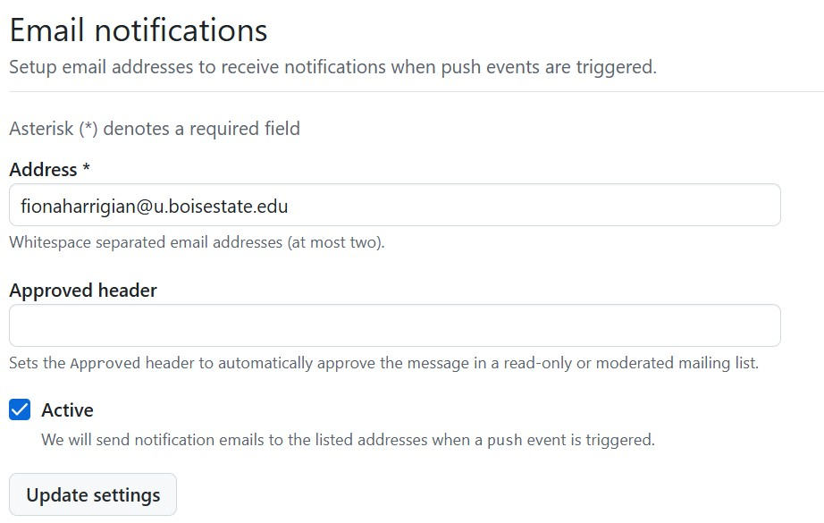

Figure 3.3: Admin email notification

Unfortunately only the admin or owner of the repository can get notifications when changes are made. So far we have not found a way to make collaborators receive these notifications. We tried using the “Watch” button in the upper right for the collaborator to receive this messages, but that did not seem to work. This remains to be explored as it can be a useful tool for remote communication.

[figure not shown]

# 4 When commiting changes:

- Do not commit at the same time, Git does not like it. It will break
- Make sure the box for the doc/file you are working on is checked before (blue tick) before you push.
- Write something on the commit box so that your partner can track changes.
- To avoid git errors, communicate with your partner when pushing and pulling.
- It is good to keep track and not get git confused.

# 5 Day 2

# 6 Learning Objectives

- Activity to practice push/pull/commit changes with partner’s repository
- How to upload/download data to and from github repository - import data into R from github

# 7 Activity for Day 2 of the Tutorial

By now, you should have created a repository of your own and linked it with a matching project in RStudio. The next piece of working in github is to practice working with a collaborator.

In pairs, you will:

- Choose one of the pair to be the admin and one to be the collaborator.
- The admin will go to the settings of their repository, then click on Collaborators in the upper left area of the settings. You’ll be prompted to login, once you do, you’ll get to the collaborators screen.

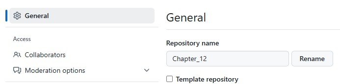

[figure not shown]

[figure not shown]

- Add your partner by clicking the add people button and searching for your partner’s GitHub account name (check with them, sometimes it may be different from their name, include numbers, etc.)

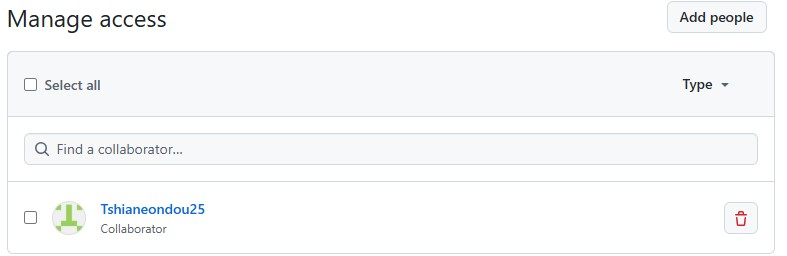

- Click Add to repository, your partner should get a code in an email to access your repository.
- Once the collaborator partner finds the admin’s repository, click on the green code button in the upper right hand corner.

[figure not shown]

- Copy the HTTPS URL with the box button to the right of the url. Follow the directions to clone your repository in RStudio as presented in section 2.2.

[figure not shown]

- Once each of you have the repository open in RStudio, one will go first, writing a sentence in the README.md, saving the your local file, committing the change (Figure 3.4)), pushing the change to the remote GitHub repository file, then the other partner pulls that change with the down pull arrow and adds their own sentence.
- Do a repeat of this exercise until you have 3 sentences each (or 1 each for time).
- Have conversation with each other (Fiona and Tshia will push and pull and demonstrate on the projector).

# 8 Import data into R from github repository

As you read more papers, interact with collaborators, and become a scientist doing extremely reproducible science, you will likely need to bring data from a public GitHub repository into your own computer and into R.

## 8.1 Public Repositories

- One example of a public repository is Sven’s repository for this class [Reproducible 603](https://github.com/svenbuerki/EEB603_Reproducible_Science). Following the link, you can see his repository, with all the folders and files inside displayed in a list. If you scroll to the bottom, you can see the README with information about this repository/class.
- Another example of a public repository is one that was made as part of a paper submission. Fiona read a cool microbial ecology paper that tracked the ecological and evolutionary responses of Curtobacterium over an elevation gradient in Southern California. In the paper, there is a section that says Data Availability. Following the [Link](https://github.com/alex-b-chase/curtoEvol) to their github, we can see a similar set of folders and files, as well as a README.

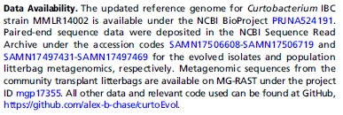

- For either repository, find a data file. Usually, you will have the specific data in mind and may have background for the name you are looking for. However, sometimes repositories can be unclear. Use what we have learned in class to identify data, whether a .csv file, a .txt file, or a .xlsx file.

## 8.2 Downloading data, uploading data, importing into RStudio project

Download the data file by clicking on the Download raw file button. It will now be on your computer. Practice uploading data to your own GitHub repository by returning to your repository, clicking the add file button next to the green code button, then Upload files in the dropdown. You can drag files into the box or choose your files. Make sure to commit your changes in the section underneath the box.

## 8.3 Relevant resources

[2nd edition reproducible Research with R and Rstudio](https://englianhu.wordpress.com/wp-content/uploads/2016/01/reproducible-research-with-r-and-studio-2nd-edition.pdf)

[3RD edition reproducuble Research with R and Rstudio](https://boisestate.on.worldcat.org/search?queryString=gandrud%20reproducible&bookReviews=off&idDetect=true&clusterResults=true&groupVariantRecords=false)

[Github for dummies](https://www.youtube.com/watch?v=mJ-qvsxPHpY&t=859s)

[Github control version](https://www.youtube.com/watch?v=HVsySz-h9r4&t=9s)